## Question No.9

**(a)**

```r
library(ISLR)
library(MASS)
library(leaps)
set.seed(1)
attach(Boston)
```

```r
polyfit = lm(nox~poly(dis,3), data=Boston)
summary(polyfit)
```

```
##
## Call:
## lm(formula = nox ~ poly(dis, 3), data = Boston)
##
## Residuals:
##       Min        1Q    Median        3Q       Max
## -0.121130 -0.040619 -0.009738  0.023385  0.194904
##
## Coefficients:
##                Estimate Std. Error t value Pr(>|t|)
## (Intercept)    0.554695   0.002759 201.021  < 2e-16 ***
## poly(dis, 3)1 -2.003096   0.062071 -32.271  < 2e-16 ***
## poly(dis, 3)2  0.856330   0.062071  13.796  < 2e-16 ***
## poly(dis, 3)3 -0.318049   0.062071  -5.124 4.27e-07 ***
## ---
## Signif. codes:  0 '***' 0.001 '**' 0.01 '*' 0.05 '.' 0.1 ' ' 1
##
## Residual standard error: 0.06207 on 502 degrees of freedom
## Multiple R-squared:  0.7148, Adjusted R-squared:  0.7131
## F-statistic: 419.3 on 3 and 502 DF,  p-value: < 2.2e-16
```

```r
range(dis)
```

```
## [1]  1.1296 12.1265
```

making grid of values to predict on.

```r
dis.grid = seq(from=range(dis)[1], to=range(dis)[2], by=0.1)
preds= predict(polyfit, newdata=list(dis=dis.grid))
```

Plotting the data and fit

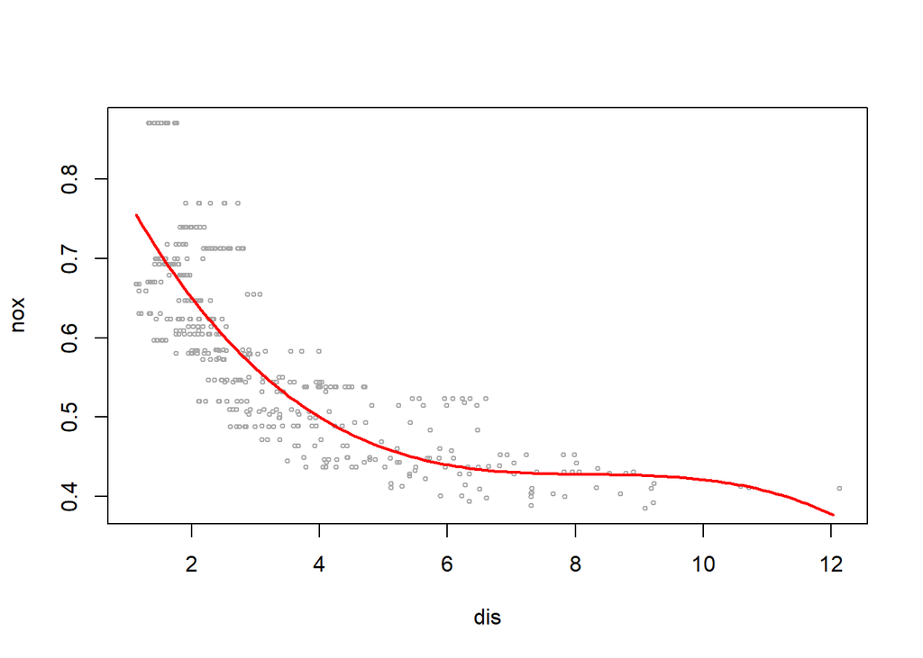

```r
plot(dis, nox, cex=0.5, col="darkgrey")
lines(dis.grid,preds, lwd=2, col="red")
```

from plot we can see that all polynomial terms are significant and it fits the data well.

**(b)**

```r
poly.errors = rep(NA,10)

for(i in 1:10){
   poly.fit = lm(nox~poly(dis,i), data= Auto)
   poly.errors[i] = deviance(poly.fit)
}
poly.errors
```

```
##  [1] 2.768563 2.035262 1.934107 1.932981 1.915290 1.878257 1.849484
##  [8] 1.835630 1.833331 1.832171
```

Training RSS decreases monotonically as degree of polynomial fit increases.

**(c)**

```r
library(boot)
cv.error = rep(NA,15)

for(i in 1:15){
  glm.fit = glm(nox~poly(dis,i), data= Boston)
  cv.error[i] = cv.glm(Boston, glm.fit, K=10)$delta[2]
}
which.min(cv.error)
```

```
## [1] 4
```

Plotting cross validation errors:

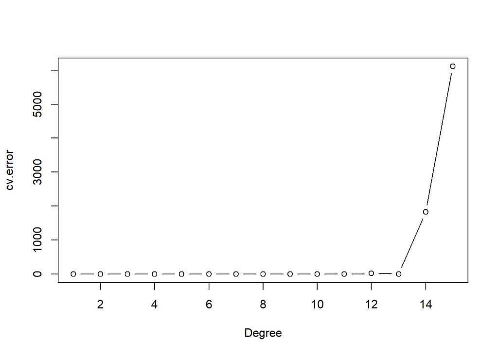

```r
plot(1:15, cv.error, xlab="Degree", type="b")
```

**(d)**

```r
library(splines)
s.fit = lm(nox~bs(dis, df=4, knots = c(4,7,11)), data= Boston)
summary(s.fit)
```

```
##
## Call:
## lm(formula = nox ~ bs(dis, df = 4, knots = c(4, 7, 11)), data = Boston)
##
## Residuals:
##       Min        1Q    Median        3Q       Max
## -0.124567 -0.040355 -0.008702  0.024740  0.192920
##
## Coefficients:
##                                       Estimate Std. Error t value Pr(>|t|)
## (Intercept)                            0.73926    0.01331  55.537  < 2e-16
## bs(dis, df = 4, knots = c(4, 7, 11))1 -0.08861    0.02504  -3.539  0.00044
## bs(dis, df = 4, knots = c(4, 7, 11))2 -0.31341    0.01680 -18.658  < 2e-16
## bs(dis, df = 4, knots = c(4, 7, 11))3 -0.26618    0.03147  -8.459 3.00e-16
## bs(dis, df = 4, knots = c(4, 7, 11))4 -0.39802    0.04647  -8.565  < 2e-16
## bs(dis, df = 4, knots = c(4, 7, 11))5 -0.25681    0.09001  -2.853  0.00451
## bs(dis, df = 4, knots = c(4, 7, 11))6 -0.32926    0.06327  -5.204 2.85e-07
##
## (Intercept)                           ***
## bs(dis, df = 4, knots = c(4, 7, 11))1 ***
## bs(dis, df = 4, knots = c(4, 7, 11))2 ***
## bs(dis, df = 4, knots = c(4, 7, 11))3 ***
## bs(dis, df = 4, knots = c(4, 7, 11))4 ***
## bs(dis, df = 4, knots = c(4, 7, 11))5 **
## bs(dis, df = 4, knots = c(4, 7, 11))6 ***
## ---
## Signif. codes:  0 '***' 0.001 '**' 0.01 '*' 0.05 '.' 0.1 ' ' 1
##
## Residual standard error: 0.06185 on 499 degrees of freedom
## Multiple R-squared:  0.7185, Adjusted R-squared:  0.7151
## F-statistic: 212.3 on 6 and 499 DF,  p-value: < 2.2e-16
```

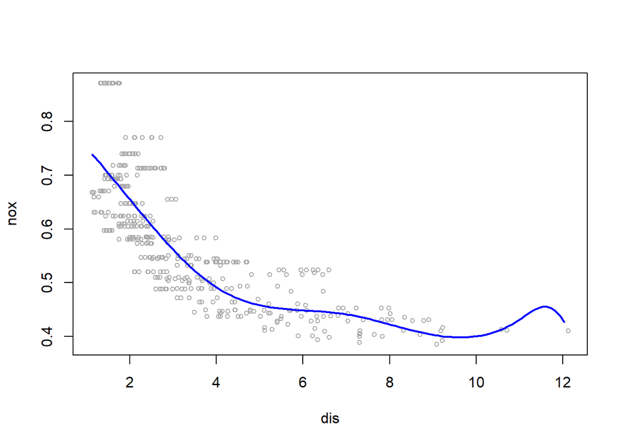

```r
s.pred = predict(s.fit, newdata=list(dis=dis.grid))
plot(nox~dis, data=Boston, col="darkgrey", cex=0.7)
lines(dis.grid, s.pred, col="blue", lwd=2)
```

**(e)**

We fit regression splines with df ranging from 3 to 16.

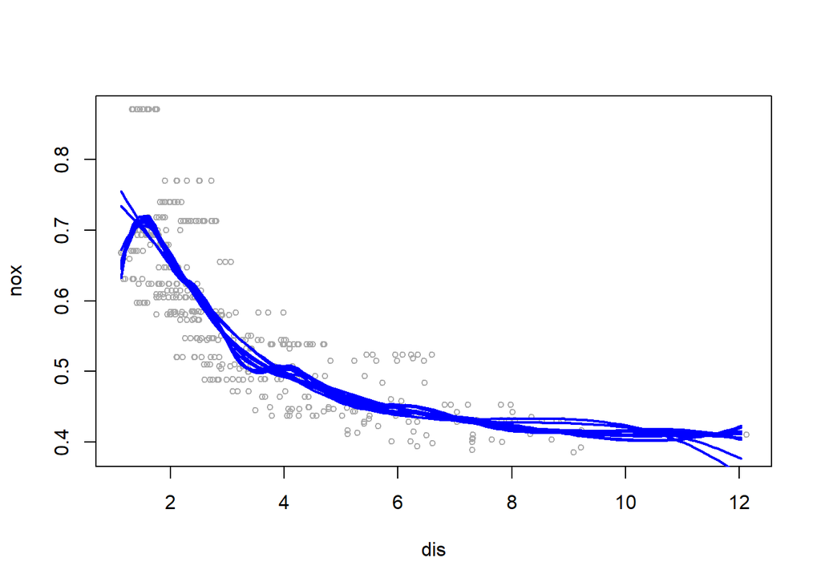

```r
plot(nox~dis, data=Boston, col="darkgrey", cex=0.7)
errors = rep(NA,16)
for (df in 3:16){
  s.fit = lm(nox~bs(dis, df = df), data= Boston)
  errors[df] = mean(s.fit$residuals^2)
  s.pred = predict(s.fit , newdata=list(dis = dis.grid))
lines(dis.grid, s.pred, col="blue", lwd=2)

}
```

```r
errors
```

```
##  [1]          NA          NA 0.003822345 0.003799951 0.003636705
##  [6] 0.003624439 0.003616372 0.003590899 0.003608009 0.003542559
## [11] 0.003551367 0.003535571 0.003522432 0.003521419 0.003523316
## [16] 0.003524794
```

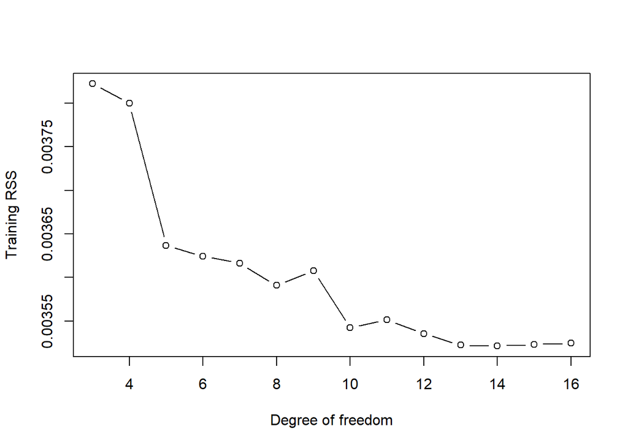

```r
plot(3:16, errors[-c(1,2)], type="b", ylab="Training RSS", xlab="Degree of freedom")
```

**(f)** Now, using cross validation to select best degrees of freedom. taking range of degrees of freedom from 3 to 16.

```r
cv.error1 = rep(NA, 16)
for(df in 3:16){
  s.fit = glm(nox~bs(dis, df = df), data= Boston)
  cv.error1[df] = cv.glm(Boston, s.fit, K=10)$delta[2]
}
```

```r
cv.error1
```

```
##  [1]          NA          NA 0.003890707 0.003889519 0.003716883
##  [6] 0.003711668 0.003672450 0.003701515 0.003717864 0.003737486
## [11] 0.003684316 0.003641992 0.003776259 0.003712300 0.003736088
## [16] 0.003815883
```

Plotting errors:

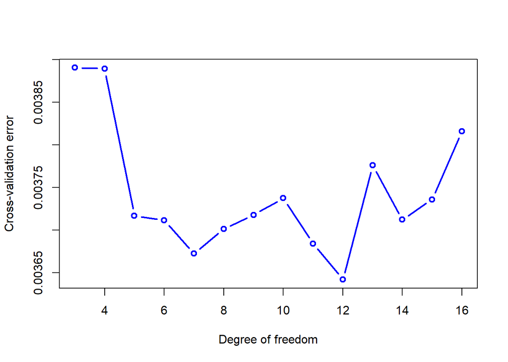

```r
plot(3:16, cv.error1[-c(1,2)], xlab="Degree of freedom",ylab = "Cross-validation error", lwd=2, col="blue", type="b")
```

CV error is minimum for 12 degrees of freedom.

## Question no.-10

**(a)**

```r
dim(College)
```

```
## [1] 777  18
```

```r
sum(is.na(College))
```

```
## [1] 0
```

using 70% data as training set and 30% as test.

```r
train = sample(nrow(College), nrow(College)*0.7)
test = -train
college.train = College[train,]
college.test = College[test,]
```

```r
names(College)
```

```
##  [1] "Private"     "Apps"        "Accept"      "Enroll"      "Top10perc"
##  [6] "Top25perc"   "F.Undergrad" "P.Undergrad" "Outstate"    "Room.Board"
## [11] "Books"       "Personal"    "PhD"         "Terminal"    "S.F.Ratio"
## [16] "perc.alumni" "Expend"      "Grad.Rate"
```

Using `Outstate` as reponse and other variables as predictors performing forward subset selection.

```r
reg.fwd = regsubsets(Outstate~. , data=College, nvmax=dim(College)[2]-1, method= "forward")
regfwd.summary = summary(reg.fwd)
```

selecting best model based on Cp:

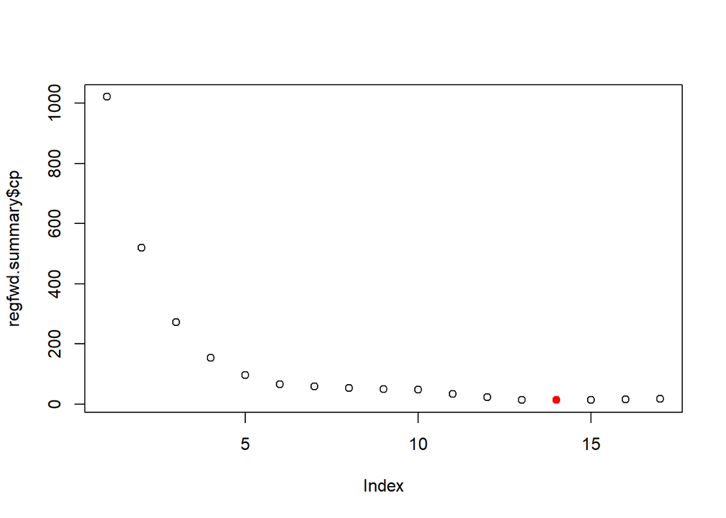

```r
plot(regfwd.summary$cp)
points(which.min(regfwd.summary$cp), regfwd.summary$cp[which.min(regfwd.summary$cp)], pch=19, col="red")
```

Mimimum cp is for 14 variable model.

**(c)** Now, we will select model using validation set.

```r
regfit.fwd  = regsubsets(Outstate~. , data=college.train, nvmax = dim(College)[2]-1, method="forward")
```

We will make predictions on test set:

```r
val.errors = rep(NA,17)
x.test = model.matrix(Outstate~. , data=college.test)
for(i in 1:17){
  coefi = coef(regfit.fwd, id = i)
  pred = x.test[,names(coefi)]%*%coefi
  val.errors[i] = mean((college.test[,"Outstate"]-pred)^2)
}
```

plotting errors:

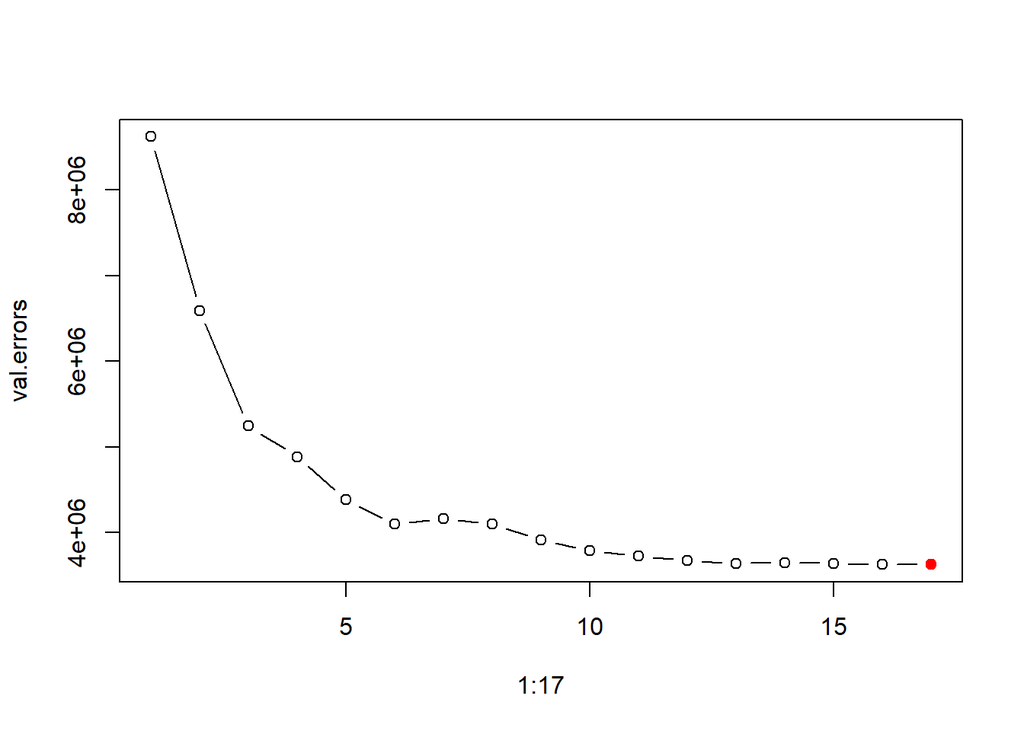

```r
plot(1:17, val.errors, type="b")
points(which.min(val.errors), val.errors[which.min(val.errors)], pch= 19, col="red")
```

From plot we can see that minimum error is at 17 variabales but there is not much significant change in error from 11 variables.

```r
which(summary(regfit.fwd)$which[11,-1])
```

```
##  PrivateYes        Apps      Accept      Enroll   Top10perc  Room.Board
##           1           2           3           4           5           9
##         PhD    Terminal perc.alumni      Expend   Grad.Rate
##          12          13          15          16          17
```

Above are the 11 features. **GAM**

```r
library(splines)
library(gam)
```

```r
gam.fit = gam(Outstate~ Private + s(Apps, df=2)+ s(Accept, df=2)+ s(Top10perc, df=2)+ s(F.Undergrad, df=2)+ s(Room.Board, df=2)+ s(Personal, df=2)+ s(Terminal, df=2) + s(perc.alumni, df=2)+ s(Expend, df=2) + s(Grad.Rate, df=2), data=college.train)
```

plotting:

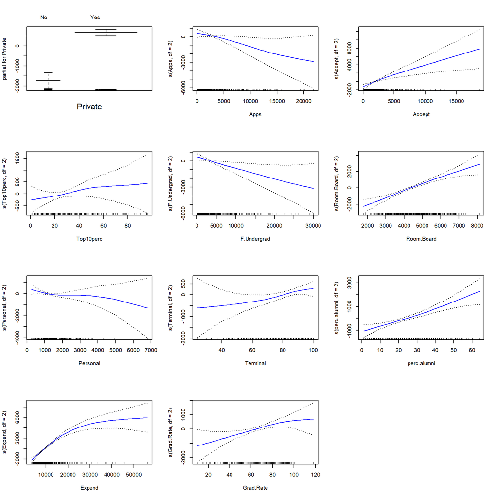

```r
par(mfrow=c(4,3))
plot(gam.fit, se= TRUE, col="blue")
```

We will now find error on test set

```r
gam.pred = predict(gam.fit, newdata = college.test )
gam.err = mean((college.test$Outstate - gam.pred)^2)
gam.err
```

```
## [1] 3301665
```

We will now find test R<sup>2</sup>. Here, gam.tss is total sum of squares which is no model error.

```r
gam.tss = mean((college.test$Outstate - mean(college.test$Outstate))^2)
test.r2 = 1 - (gam.err/gam.tss)
test.r2
```

```
## [1] 0.7772575
```

**(d)**

```r
summary(gam.fit)
```

```
##
## Call: gam(formula = Outstate ~ Private + s(Apps, df = 2) + s(Accept,
##     df = 2) + s(Top10perc, df = 2) + s(F.Undergrad, df = 2) +
##     s(Room.Board, df = 2) + s(Personal, df = 2) + s(Terminal,
##     df = 2) + s(perc.alumni, df = 2) + s(Expend, df = 2) + s(Grad.Rate,
##     df = 2), data = college.train)
## Deviance Residuals:
##      Min       1Q   Median       3Q      Max
## -6072.95 -1199.29   -13.52  1242.85  8545.28
##
## (Dispersion Parameter for gaussian family taken to be 3558416)
##
##     Null Deviance: 9090641508 on 542 degrees of freedom
## Residual Deviance: 1853935423 on 521.0002 degrees of freedom
## AIC: 9755.569
##
## Number of Local Scoring Iterations: 2
##
## Anova for Parametric Effects
##                         Df     Sum Sq    Mean Sq  F value    Pr(>F)
## Private                  1 2791790005 2791790005 784.5598 < 2.2e-16 ***
## s(Apps, df = 2)          1 1123474895 1123474895 315.7233 < 2.2e-16 ***
## s(Accept, df = 2)        1   93229813   93229813  26.1998 4.338e-07 ***
## s(Top10perc, df = 2)     1  790993948  790993948 222.2882 < 2.2e-16 ***
## s(F.Undergrad, df = 2)   1  222721092  222721092  62.5900 1.537e-14 ***
## s(Room.Board, df = 2)    1  673174039  673174039 189.1780 < 2.2e-16 ***
## s(Personal, df = 2)      1   16708797   16708797   4.6956  0.030693 *
## s(Terminal, df = 2)      1   99892573   99892573  28.0722 1.728e-07 ***
## s(perc.alumni, df = 2)   1  236397055  236397055  66.4332 2.709e-15 ***
## s(Expend, df = 2)        1  384377106  384377106 108.0192 < 2.2e-16 ***
## s(Grad.Rate, df = 2)     1   34952533   34952533   9.8225  0.001821 **
## Residuals              521 1853935423    3558416
## ---
## Signif. codes:  0 '***' 0.001 '**' 0.01 '*' 0.05 '.' 0.1 ' ' 1
##
## Anova for Nonparametric Effects
##                        Npar Df Npar F     Pr(F)
## (Intercept)
## Private
## s(Apps, df = 2)              1  2.725   0.09941 .
## s(Accept, df = 2)            1  4.666   0.03122 *
## s(Top10perc, df = 2)         1  1.020   0.31295
## s(F.Undergrad, df = 2)       1  0.684   0.40847
## s(Room.Board, df = 2)        1  0.975   0.32397
## s(Personal, df = 2)          1  4.447   0.03543 *
## s(Terminal, df = 2)          1  1.506   0.22027
## s(perc.alumni, df = 2)       1  0.742   0.38935
## s(Expend, df = 2)            1 59.360 6.695e-14 ***
## s(Grad.Rate, df = 2)         1  1.260   0.26216
## ---
## Signif. codes:  0 '***' 0.001 '**' 0.01 '*' 0.05 '.' 0.1 ' ' 1
```